# ANCOVA

Danielle van Os

21/01/2021

### ANCOVA - multiple groups (categorical) and a continuous predictor

ANCOVA is an extension of ANOVA where you control for one or more covariates.

A covariate is a continuous variable that is correlated with the dependent variable but is not the focus of the study.

In an ANOVA, the variance due to covariates becomes error. If it is controlled in an ANCOVA, then the error variance is less, so you more accurately assess the variance due to the factor (the IV).

Assumptions:

- **ANOVA assumptions - normality and homogeneity of variance**
- **Linearity between pairs of covariates** - if there is more than one covariate
- **Linearity between the covariates and the DV**
- **Homogeneity of regression** - the regression slope between the continuous predictor and outcome variable should be the same for all groups, or there should be no interaction between the continuous predictor and group levels in predicting the outcome variable.
- **Independence of covariate and factor** - the categorical and continuous predictors should be independent

```r
# Parameters
group_size <- 200
mean_g1 <- 10
mean_g2 <- 12
mean_g3 <- 7
sd_g1 <- 0.3
sd_g2 <- 0.3
sd_g3 <- 0.3
n_groups <- 3

# Data generation
group_1 <- mvrnorm(n = group_size, mu = mean_g1, Sigma = sd_g1, empirical = TRUE)
group_2 <- mvrnorm(n = group_size, mu = mean_g2, Sigma = sd_g2, empirical = TRUE)
group_3 <- mvrnorm(n = group_size, mu = mean_g3, Sigma = sd_g3, empirical = TRUE)
data <- c(group_1, group_2, group_3)
continuous <-data + mvrnorm(n = group_size*n_groups, mu = 0, Sigma = 2, empirical = TRUE)

# Data frame
df <- tibble(group_label = rep(c("group_1", "group_2", "group_3"), each = group_size),
             group_n = as_factor(rep(c(0, 1, 2), each = group_size)),
             group_2 = rep(c(0,1,0), each = group_size),
             group_3 = rep(c(0,0,1), each = group_size),
             y = data,
             x = continuous)
```

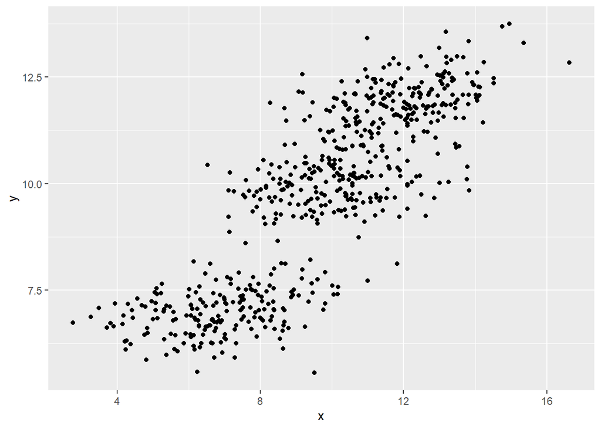

```r
ggplot(data = df, mapping = aes(x = x, y = y)) +
  geom_point()
```